# Predict cell-cell interactions from differential expression results

Brendan Innes

2019-03-08

# CCInx Usage

CCInx takes cell type transcriptomes (generally from clustered scRNAseq data) and predicts cell-cell interaction networks. It generates both node and edgelists appropriate for importing into graph visualization software such as Cytoscape, and figures showing bipartite graphs for predicted interactions between pairs of cell types.

Here we’ll demonstrate the standard use case using data from [a recent study of aging mouse brain](https://www.biorxiv.org/content/10.1101/440032v1), where differential expression testing was performed between young and aging neuronal cell types. The input data is a list of data frames, where each named list entry represents a cell type, and its data frame contains the differential expression statistics for genes in that cell type.

```r
library(CCInx)
load(system.file("DemoData/DemoDE.RData",package="CCInx"))
lapply(deL,head)
```

```
#> $DOPA
#>                pval       padj      logFC DetectPctYoung DetectPctOld
#> mt-Nd4  0.000007580 0.03565106 -0.3873342     1.00000000    0.9948718
#> mt-Cytb 0.000012300 0.03565106 -0.3685228     1.00000000    1.0000000
#> Fam3c   0.000013900 0.03565106  0.3439192     0.03731343    0.2307692
#> mt-Co3  0.000069600 0.12934011 -0.3110772     1.00000000    1.0000000
#> Sepw1   0.000098700 0.15294014 -0.6145720     0.56716418    0.5487179
#> mt-Nd1  0.000151239 0.18006463 -0.3097862     1.00000000    1.0000000
#>
#> $GABA
#>             pval     padj      logFC DetectPctYoung DetectPctOld
#> Malat1  1.11e-59 1.43e-55  0.3297557      0.9965659    0.9982379
#> mt-Nd1  1.36e-46 8.72e-43 -0.2975538      1.0000000    0.9995595
#> mt-Nd4  5.53e-46 2.37e-42 -0.3230167      0.9986264    0.9969163
#> mt-Atp6 2.23e-45 7.16e-42 -0.2668197      1.0000000    1.0000000
#> mt-Cytb 4.04e-45 1.04e-41 -0.2907866      1.0000000    0.9995595
#> mt-Co2  1.12e-33 2.39e-30 -0.2465769      1.0000000    0.9986784
#>
#> $GLUT
#>             pval        padj      logFC DetectPctYoung DetectPctOld
#> PISD    4.67e-30 5.77000e-26  0.5634818      0.7088036    0.8787879
#> Malat1  1.01e-19 6.21000e-16  0.3880324      1.0000000    0.9983165
#> Gm26917 7.02e-14 2.89000e-10  0.3507149      0.2911964    0.5101010
#> Nap1l5  1.38e-08 4.27000e-05  0.3612765      0.5959368    0.7424242
#> mt-Nd4  4.05e-08 1.00002e-04 -0.2316669      0.9977427    0.9983165
#> mt-Nd1  5.30e-08 1.09025e-04 -0.2269154      1.0000000    0.9983165
```

CCInx is run as follows. First, the nodes are scored in order to rank and filter them for inclusion in the network. Scores are scaled for ease of comparison between cell types, and converted for factors for plot colour scale.

```r
scoredGeneList <- ScoreClustGenes(GeneStatList=deL,
                                  GeneMagnitude="logFC",
                                  GeneStatistic="padj")
```

```
#> Scoring differential expression for all cell types...
```

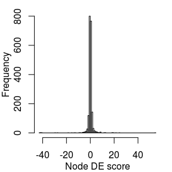

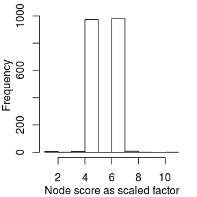

```r
par(mar=c(3,3,1,1),mgp=2:0)
hist(scoredGeneList$GABA$score,breaks=100,xlab="Node DE score",main=NA)
hist(scoredGeneList$GABA$scaledFactor,xlab="Node score as scaled factor",main=NA)
```

The network is then built using the list of scored DE gene data frames. The output of `BuildInx` is a list of dataframes serving as edge list for each pair of cell types, and `BuildInxNode` generates the corresponding node metadata. These can be exported as .csv files for use in Cytoscape.

```r
inx <- BuildInx(SCL=scoredGeneList,
                NodeScoreThreshold=0,
                EdgeScoreThreshold=0,
                species="mmusculus")
```

```
#> Building predicted cell-cell interaction networks...
```

```r
head(inx$`DOPA~GABA`)
```

```
#>                                           key       nodeA      nodeB
#> Acvr1_DOPA~Bmp3_GABA     Acvr1_DOPA~Bmp3_GABA  Acvr1_DOPA  Bmp3_GABA
#> Acvr1b_DOPA~Bmp3_GABA   Acvr1b_DOPA~Bmp3_GABA Acvr1b_DOPA  Bmp3_GABA
#> Acvr1b_DOPA~Sort1_GABA Acvr1b_DOPA~Sort1_GABA Acvr1b_DOPA Sort1_GABA
#> Acvr1c_DOPA~Bmp3_GABA   Acvr1c_DOPA~Bmp3_GABA Acvr1c_DOPA  Bmp3_GABA
#> Adam22_DOPA~App_GABA     Adam22_DOPA~App_GABA Adam22_DOPA   App_GABA
#> Adam22_DOPA~Lgi1_GABA   Adam22_DOPA~Lgi1_GABA Adam22_DOPA  Lgi1_GABA
#>                         geneA geneB cellTypeA cellTypeB proteinTypeA
#> Acvr1_DOPA~Bmp3_GABA    Acvr1  Bmp3      DOPA      GABA     Receptor
#> Acvr1b_DOPA~Bmp3_GABA  Acvr1b  Bmp3      DOPA      GABA     Receptor
#> Acvr1b_DOPA~Sort1_GABA Acvr1b Sort1      DOPA      GABA     Receptor
#> Acvr1c_DOPA~Bmp3_GABA  Acvr1c  Bmp3      DOPA      GABA     Receptor
#> Adam22_DOPA~App_GABA   Adam22   App      DOPA      GABA          ECM
#> Adam22_DOPA~Lgi1_GABA  Adam22  Lgi1      DOPA      GABA          ECM
#>                           proteinTypeB sumAbsScore sumScaledScore
#> Acvr1_DOPA~Bmp3_GABA            Ligand   0.3279953   -0.007798366
#> Acvr1b_DOPA~Bmp3_GABA           Ligand   0.4442968    0.072524397
#> Acvr1b_DOPA~Sort1_GABA        Receptor   0.9424904    0.060679421
#> Acvr1c_DOPA~Bmp3_GABA           Ligand   0.3279953   -0.007798366
#> Adam22_DOPA~App_GABA   Receptor/Ligand   1.0249311   -0.024368609
#> Adam22_DOPA~Lgi1_GABA           Ligand   0.4077522   -0.009694655
#>                        sumAbsFactor sumScaledFactor direction
#> Acvr1_DOPA~Bmp3_GABA              1               5      RtoL
#> Acvr1b_DOPA~Bmp3_GABA             1              10      RtoL
#> Acvr1b_DOPA~Sort1_GABA            2              10      None
#> Acvr1c_DOPA~Bmp3_GABA             1               5      RtoL
#> Adam22_DOPA~App_GABA              2               5      EtoR
#> Adam22_DOPA~Lgi1_GABA             1               5      EtoL
```

```r
inxNode <- BuildInxNode(INX=inx,
                        SCL=scoredGeneList)
```

```
#> Writing node metadata for cell-cell interaction networks...
```

```r
head(inxNode$`DOPA~GABA`)
```

```
#>                    node   gene cellType proteinType        pval      padj
#> Acvr1_DOPA   Acvr1_DOPA  Acvr1     DOPA        <NA> 0.270009309 1.0000000
#> Acvr1b_DOPA Acvr1b_DOPA Acvr1b     DOPA        <NA> 0.006177912 0.7650652
#> Acvr1c_DOPA Acvr1c_DOPA Acvr1c     DOPA        <NA> 0.026346381 1.0000000
#> Adam22_DOPA Adam22_DOPA Adam22     DOPA        <NA> 0.283123952 1.0000000
#> Aplp1_DOPA   Aplp1_DOPA  Aplp1     DOPA        <NA> 0.126867088 1.0000000
#> Apoe_DOPA     Apoe_DOPA   Apoe     DOPA        <NA> 0.049105272 1.0000000
#>                   logFC DetectPctYoung DetectPctOld     score scoreScaled
#> Acvr1_DOPA   0.09271058     0.06716418    0.1179487 0.0000000  0.00000000
#> Acvr1b_DOPA  0.19373405     0.05223881    0.1487179 0.1163015  0.08032276
#> Acvr1c_DOPA  0.24963477     0.21641791    0.3692308 0.0000000  0.00000000
#> Adam22_DOPA  0.08883595     0.07462687    0.1435897 0.0000000  0.00000000
#> Aplp1_DOPA   0.27071483     0.59701492    0.7692308 0.0000000  0.00000000
#> Apoe_DOPA   -0.31456176     0.61194030    0.5948718 0.0000000  0.00000000
#>             scaledFactor
#> Acvr1_DOPA             6
#> Acvr1b_DOPA            7
#> Acvr1c_DOPA            6
#> Adam22_DOPA            6
#> Aplp1_DOPA             6
#> Apoe_DOPA              6
```

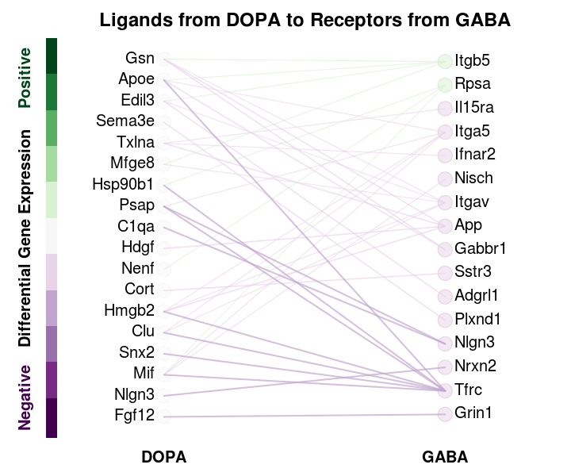

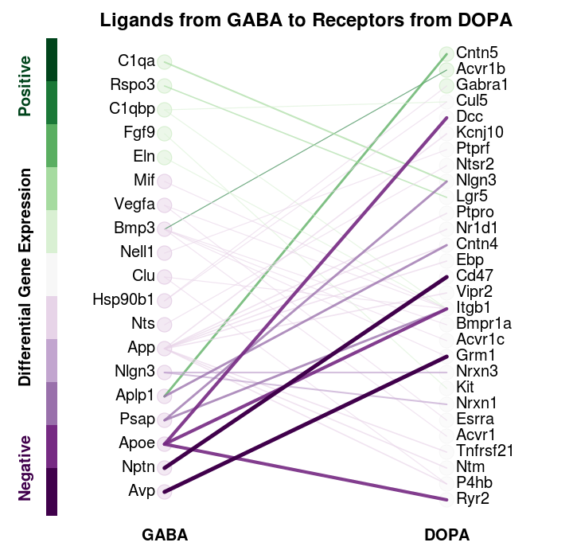

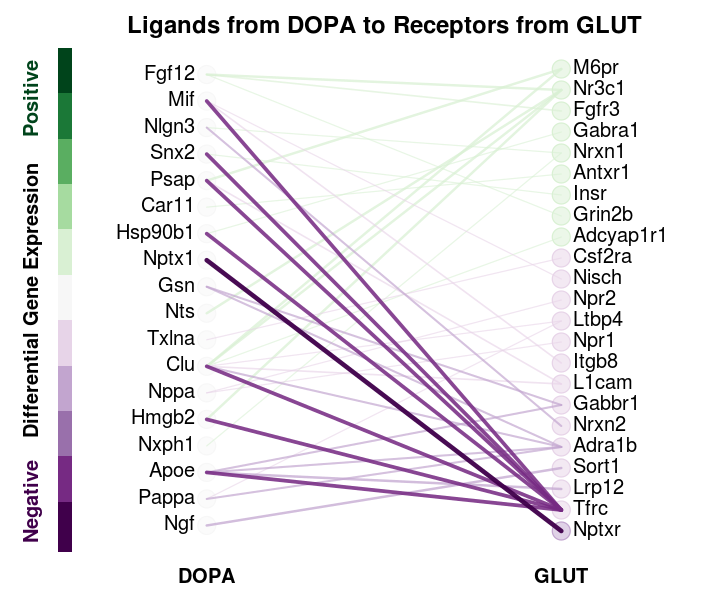

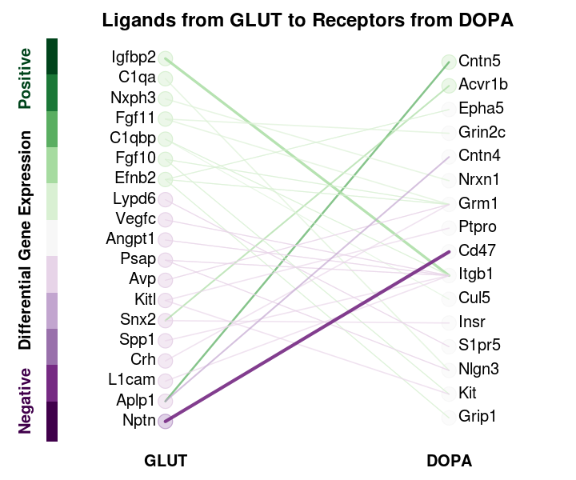

```r
PlotCCInx(INX=inx,
          INXNODE=inxNode,
          comparisons=c("DOPA~GABA","DOPA~GLUT"),
          directions=c("LtoR","RtoL"),
          topPer=20,
          imageFileType="png",
          imageFilePath="../inst/DemoData/")
```